# The Global to Grocery Link

### [Github Webpage](https://srubiii.github.io/)

## Project Overview:

Have you ever wondered why your grocery bill fluctuates so much from one week to the next? This project investigates the price correlation between marco level global economic shifts and micro level grocery consumer behavior. Using global commodity product indices like energy, agricultural, and livestock with consumer level transactions like quantity, unit price, and final bill amount will show how much the global indices affect the consumer transactions. Ultimately, what factors most strongly influence grocery spending, and how do global commodity prices affect both transaction behavior and total spending amount?

### Dataset 1: [Grocery Store Sales](https://www.kaggle.com/datasets/pratyushpuri/grocery-store-sales-dataset-in-2025-1900-record)

This dataset from Kaggle includes 1900 rows of data that describes customer behavior as well as prices per unit of each item and how many where purchased. The data is from 2023 to 2025. This data provides the micro level perspective needed for calculating monthly averages and unit prices per category.

Columns include: customer_id, store_name, transaction_date, product_name, quantity, unit_price, total_amount, discount_amount, final_amount, and loyalty_points.

### Dataset 2: [World Bank Commodity Pricing Intelligence](https://www.kaggle.com/datasets/kanchana1990/world-bank-commodity-price-intelligence-19602026)

This dataset from Kaggle includes global commodities pricing per month that showcase energy, grains, meats, and other food indices. The data is from 1960 to 2026. This data provides a global prospective to help identify commodity changes which influence consumer prices and retail costs.

Columns include commodities like: coal, oil, natural gas, wheat, sugar, coffee, sugar, metals, rice, meats and many more.

## Project Sections:

1. Data Extraction and Cleaning
2. Analysis of Data
3. Modeling Data
4. Conclusion

## 1. Extraction, Transform, and Load (ETL):

This section focuses on data extractiion for two csv files, data cleaning, and merging of two datasets.

### Dataset 1:

This is a grocery stores dataset as mentioned above from dataset 1. This dataset is a source for dependent variables in modeling that help measure how consumer cost and demands fluctuate over time.

To start the data extraction process pandas will be used to get the data from the csv file. The goal is to be able to create multiple dataframes with this data for analysis and merging.

```python
import pandas as pd

#reading in Grocery Dataset csv
grocery_df = pd.read_csv('grocery_chain_data.csv')
```

Next convert transaction_date into a datatime object and then extract just the Month and Year. The reason why only Month and Year are used is to match Dataset 2 as well as because there are mulitple transactions that happen each day and making them into a month allows for easier analysis.

```python
#text to datetime object and getting just month and year
grocery_df["transaction_date"] = pd.to_datetime(grocery_df["transaction_date"])

grocery_df["month"] = grocery_df["transaction_date"].dt.to_period("M")
```

Fill all empty columns with the word "Unknown". This makes it easy when formulas or any aggregation is done like in the next step.

```python
#all NaN are going to be 'Unknown'
# grocery_df = grocery_df.fillna("Unknown")
categorical_cols = grocery_df.select_dtypes(include=['object']).columns
grocery_df[categorical_cols] = grocery_df[categorical_cols].fillna("Unknown")
```

Grouped all transactions by the month column to calculation Sum and Mean for each month. The reason why both are being used are because Sum gives us the total store performance while mean give the average of customer transaction.

```python
#using mean for the average customer spend per transaction
grocery_monthly = grocery_df.groupby('month').agg(
    unit_price=('unit_price', 'mean'),
    quantity_mean=('quantity', 'mean'),
    quantity=('quantity', 'sum'),
    final_amount_mean=('final_amount', 'mean'),
    final_amount=('final_amount', 'sum'),
    discount_amount=('discount_amount', 'mean')
).reset_index()

#displaying table and data types
display(grocery_df.dtypes)

grocery_df.head()
```

```
customer_id                  int64
store_name                  object
transaction_date    datetime64[ns]
aisle                       object
product_name                object
quantity                   float64
unit_price                 float64
total_amount               float64
discount_amount            float64
final_amount               float64
loyalty_points               int64
month                    period[M]
dtype: object
```

|  | customer_id | store_name | transaction_date | aisle | product_name | quantity | unit_price | total_amount | discount_amount | final_amount | loyalty_points | month |
| --- | --- | --- | --- | --- | --- | --- | --- | --- | --- | --- | --- | --- |
| 0 | 2824 | GreenGrocer Plaza | 2023-08-26 | Produce | Pasta | 2.0 | 7.46 | 14.92 | 0.00 | 14.92 | 377 | 2023-08 |
| 1 | 5506 | ValuePlus Market | 2024-02-13 | Dairy | Cheese | 1.0 | 1.85 | 1.85 | 3.41 | -1.56 | 111 | 2024-02 |
| 2 | 4657 | ValuePlus Market | 2023-11-23 | Bakery | Onions | 4.0 | 7.38 | 29.52 | 4.04 | 25.48 | 301 | 2023-11 |
| 3 | 2679 | SuperSave Central | 2025-01-13 | Snacks & Candy | Cereal | 3.0 | 5.50 | 16.50 | 1.37 | 15.13 | 490 | 2025-01 |
| 4 | 9935 | GreenGrocer Plaza | 2023-10-13 | Canned Goods | Orange Juice | 5.0 | 8.66 | 43.30 | 1.50 | 41.80 | 22 | 2023-10 |

### Dataset 2:

This is the Commodity Price list from Dataset 2 mentioned above. This dataset represents the global commodity prices that flucatuate at different times.

First we load in another csv file then we drop the year column because we have a date column already. This will help us only have important and relevant features to use for our models.

```python
#Reading in csv and dropping columns
commodity_df = pd.read_csv("wb_commodity_price_intelligence_1960_2026.csv")

commodity_df = commodity_df.drop(columns=["year"])
```

Start by converting the date into Month and Year only to match Dataset 1. Then filter the date ranges to match the same date ranges from Dataset 1. This will help with finding relationships between both datasets during the same time period.

```python
#date to month and year only
commodity_df["date"] = pd.to_datetime(commodity_df["date"])
commodity_df["month"] = commodity_df["date"].dt.to_period("M")

#only want dates from august 2023 to august 2025 to match dataset 1
commodity_df = commodity_df[(commodity_df["month"] >= "2023-08") &
                            (commodity_df["month"] <= "2025-08")]
```

Each commodity is order by row instead of having a row dedicated to each month. Used the pivot function to get each commodity to have a column based on the month row. This helps if any commodity becomes a feature because it will be in columns for a model to use.

```python
#commodity list
commodities = [
    # energy / transport
    "Crude oil, average", "Crude oil, Brent", "Crude oil, Dubai", "Crude oil, WTI", "Natural gas, US", "Natural gas index",
    # grains
    "Wheat, US HRW", "Rice, Thai 5%", "Maize",
    # meat / protein
    "Chicken", "Beef", "Fish meal",
    # fruit
    "Banana, US","Orange",
    # sugar / oil / processed food
    "Sugar, world", "Palm oil", "Soybean oil", "Sunflower oil", "Groundnut oil", "Coconut oil",
    # animal feed / dairy proxy
    "Soybeans",
]
#only getting the ones in the list for the pivot table
commodity_small = commodity_df[commodity_df["commodity_name"].isin(commodities)]

#pivot table
commodity_wide = commodity_small.pivot(
    index="month",
    columns="commodity_name",
    values="price_nominal_usd"
).reset_index()
```

Changed how the column names were and also used the .ffill() method to get the last known price if a month is missing a value. This is because there is sometimes gaps in the months if nothing was reported and no nulls are found.

```python
commodity_wide.columns = [
    col.lower().replace(",", "")
    .replace(" ", "_")
    for col in commodity_wide.columns]

commodity_wide = commodity_wide.ffill()


#displaying table and data types

display(commodity_wide.dtypes)

commodity_wide.head()
```

```
month                period[M]
banana_us              float64
beef                   float64
chicken                float64
coconut_oil            float64
crude_oil_brent        float64
crude_oil_dubai        float64
crude_oil_wti          float64
crude_oil_average      float64
fish_meal              float64
groundnut_oil          float64
maize                  float64
natural_gas_index      float64
natural_gas_us         float64
orange                 float64
palm_oil               float64
rice_thai_5%           float64
soybean_oil            float64
soybeans               float64
sugar_world            float64
sunflower_oil          float64
wheat_us_hrw           float64
dtype: object
```

|  | month | banana_us | beef | chicken | coconut_oil | crude_oil_brent | crude_oil_dubai | crude_oil_wti | crude_oil_average | fish_meal | ... | natural_gas_index | natural_gas_us | orange | palm_oil | rice_thai_5% | soybean_oil | soybeans | sugar_world | sunflower_oil | wheat_us_hrw |
| --- | --- | --- | --- | --- | --- | --- | --- | --- | --- | --- | --- | --- | --- | --- | --- | --- | --- | --- | --- | --- | --- |
| 0 | 2023-08 | 1.557013 | 4.726154 | 1.424562 | 1099.09 | 86.163 | 86.61 | 81.40 | 84.724333 | 1882.62 | ... | 93.089279 | 2.5845 | 1.658860 | 860.82 | 635.0 | 1126.53 | 583.93 | 0.528006 | 989.42 | 315.82 |
| 1 | 2023-09 | 1.563902 | 4.903075 | 1.537480 | 1071.67 | 94.000 | 93.08 | 89.58 | 92.220000 | 1851.82 | ... | 95.230103 | 2.6395 | 1.769309 | 829.60 | 620.0 | 1111.63 | 619.04 | 0.579595 | 894.81 | 314.68 |
| 2 | 2023-10 | 1.570792 | 4.979685 | 1.583950 | 1046.43 | 91.061 | 90.62 | 85.57 | 89.083667 | 1832.74 | ... | 114.104614 | 2.9886 | 2.034589 | 804.26 | 590.0 | 1133.87 | 529.57 | 0.567028 | 910.17 | 298.10 |
| 3 | 2023-11 | 1.550123 | 4.883233 | 1.667497 | 1114.55 | 83.183 | 83.45 | 77.43 | 81.354333 | 1869.68 | ... | 110.370695 | 2.7084 | 2.061990 | 830.47 | 598.0 | 1118.39 | 553.05 | 0.574965 | 943.60 | 283.55 |
| 4 | 2023-12 | 1.565280 | 4.791374 | 1.633600 | 1108.81 | 77.858 | 77.22 | 72.08 | 75.719333 | 1847.44 | ... | 95.165272 | 2.5265 | 1.897585 | 813.51 | 644.0 | 1062.48 | 547.43 | 0.478182 | 944.03 | 291.12 |

5 rows × 22 columns

### Merging Both Datasets:

Perfomed an inner join on the month column in both datasets. This creates a single dataframe/table where both grocery and global commodity prices are together for analysis and modeling.

```python
#inner join both datasets
joined_df_one = pd.merge(grocery_monthly, commodity_wide, on="month", how="inner")

#crude oil master is the avg of all crude oils
joined_df_one['crude_oil_master'] = joined_df_one[['crude_oil_average', 'crude_oil_brent', 'crude_oil_dubai', 'crude_oil_wti']].mean(axis=1)

display(joined_df_one.dtypes)
joined_df_one.head()
```

```
month                period[M]
unit_price             float64
quantity_mean          float64
quantity               float64
final_amount_mean      float64
final_amount           float64
discount_amount        float64
banana_us              float64
beef                   float64
chicken                float64
coconut_oil            float64
crude_oil_brent        float64
crude_oil_dubai        float64
crude_oil_wti          float64
crude_oil_average      float64
fish_meal              float64
groundnut_oil          float64
maize                  float64
natural_gas_index      float64
natural_gas_us         float64
orange                 float64
palm_oil               float64
rice_thai_5%           float64
soybean_oil            float64
soybeans               float64
sugar_world            float64
sunflower_oil          float64
wheat_us_hrw           float64
crude_oil_master       float64
dtype: object
```

|  | month | unit_price | quantity_mean | quantity | final_amount_mean | final_amount | discount_amount | banana_us | beef | chicken | ... | natural_gas_us | orange | palm_oil | rice_thai_5% | soybean_oil | soybeans | sugar_world | sunflower_oil | wheat_us_hrw | crude_oil_master |
| --- | --- | --- | --- | --- | --- | --- | --- | --- | --- | --- | --- | --- | --- | --- | --- | --- | --- | --- | --- | --- | --- |
| 0 | 2023-08 | 17.594828 | 3.086207 | 179.0 | 49.959310 | 2897.64 | 4.511034 | 1.557013 | 4.726154 | 1.424562 | ... | 2.5845 | 1.658860 | 860.82 | 635.0 | 1126.53 | 583.93 | 0.528006 | 989.42 | 315.82 | 84.724333 |
| 1 | 2023-09 | 14.829342 | 2.973684 | 226.0 | 41.373158 | 3144.36 | 4.606711 | 1.563902 | 4.903075 | 1.537480 | ... | 2.6395 | 1.769309 | 829.60 | 620.0 | 1111.63 | 619.04 | 0.579595 | 894.81 | 314.68 | 92.220000 |
| 2 | 2023-10 | 14.181313 | 3.141414 | 311.0 | 38.062424 | 3768.18 | 3.682323 | 1.570792 | 4.979685 | 1.583950 | ... | 2.9886 | 2.034589 | 804.26 | 590.0 | 1133.87 | 529.57 | 0.567028 | 910.17 | 298.10 | 89.083667 |
| 3 | 2023-11 | 16.275733 | 3.106667 | 233.0 | 47.866133 | 3589.96 | 4.951467 | 1.550123 | 4.883233 | 1.667497 | ... | 2.7084 | 2.061990 | 830.47 | 598.0 | 1118.39 | 553.05 | 0.574965 | 943.60 | 283.55 | 81.354333 |
| 4 | 2023-12 | 15.310694 | 2.944444 | 212.0 | 40.171528 | 2892.35 | 4.228333 | 1.565280 | 4.791374 | 1.633600 | ... | 2.5265 | 1.897585 | 813.51 | 644.0 | 1062.48 | 547.43 | 0.478182 | 944.03 | 291.12 | 75.719333 |

5 rows × 29 columns

## 2. Exploratory Data Analysis (EDA):

### Price Transmission Trend Analysis

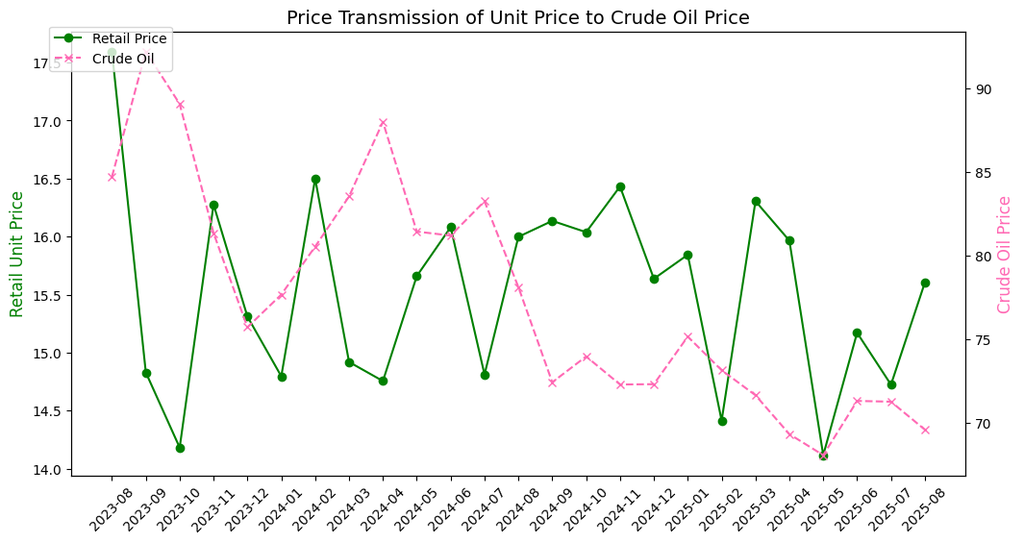

```python
import matplotlib.pyplot as plt
#make month a string for plotting
joined_df_one['month_str'] = joined_df_one['month'].astype(str)

#figure size and two axis
fig, ax1 = plt.subplots(figsize=(12, 6))
ax2 = ax1.twinx()

#plotting unit price green line
ax1.plot(joined_df_one['month_str'], joined_df_one['unit_price'], color='green', marker='o', label='Retail Price')
ax1.set_ylabel('Retail Unit Price', color='green', fontsize=12)

#plotting crude oil master avg
ax2.plot(joined_df_one['month_str'], joined_df_one['crude_oil_master'], color='hotpink', linestyle='--', marker='x', label='Crude Oil')
ax2.set_ylabel('Crude Oil Price', color='hotpink', fontsize=12)

#graph outputs and labels
plt.title("Price Transmission of Unit Price to Crude Oil Price", fontsize=14)
ax1.tick_params(axis='x', rotation=45)
fig.legend(loc="upper left", bbox_to_anchor=(0.1,0.9))
plt.show()
```

### Correlation Heatmap of Features

A correlation heatmap showing the correlations between potential features in a model. These features include both global and grocery variables. In the heatmap, final amount and quantity have a very strong relationship 0.95 this will need further investigation with a model, but there is definitely a relationship.

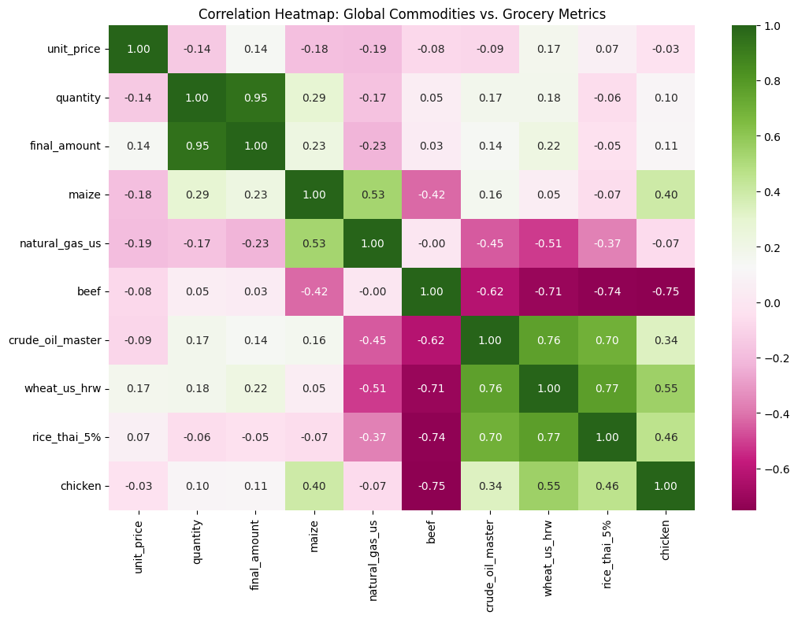

```python
import seaborn as sns
import matplotlib.pyplot as plt

#grab potential feature variables to see relationships for a model
correlation_df = joined_df_one[['unit_price', 'quantity', 'final_amount', "maize",'natural_gas_us', 'beef', 'crude_oil_master', 'wheat_us_hrw','rice_thai_5%', 'chicken']]

#correlation matrix calculation
corr_matrix = correlation_df.corr()

#generating heatmap plot
plt.figure(figsize=(12, 8))
sns.heatmap(corr_matrix, annot=True, cmap='PiYG', fmt=".2f")
plt.title('Correlation Heatmap: Global Commodities vs. Grocery Metrics')
plt.show()
```

### Oil Comparison against Unit Price

This heatmap graph compares the different crude oil prices against the grocery store unit price. It proves that all the crude oil benchmarks are very similar and they affect the unit price very similarly. This allows for only one crude oil to be used in the model as a feature. The feature to be used will be the crude oil master because it has the highest relationship between all the other crude oils.

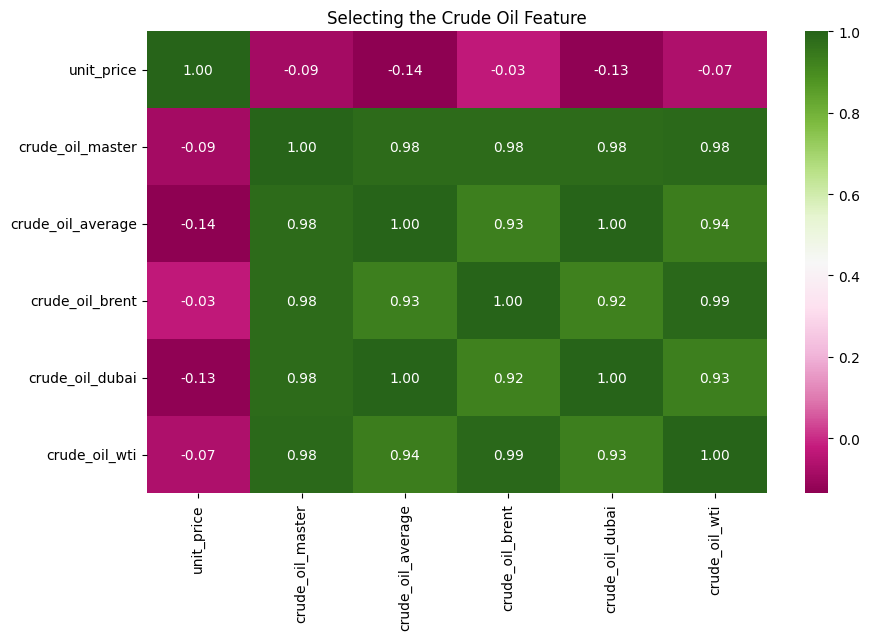

```python
#grabbing crude oil variables
oil_corr = joined_df_one[['unit_price', 'crude_oil_master','crude_oil_average', 'crude_oil_brent', 'crude_oil_dubai', 'crude_oil_wti']].corr()

#output of graph
plt.figure(figsize=(10, 6))
sns.heatmap(oil_corr, annot=True, cmap='PiYG', fmt=".2f")
plt.title("Selecting the Crude Oil Feature")
plt.show()
```

### Global Link: Spending versus Energy Costs

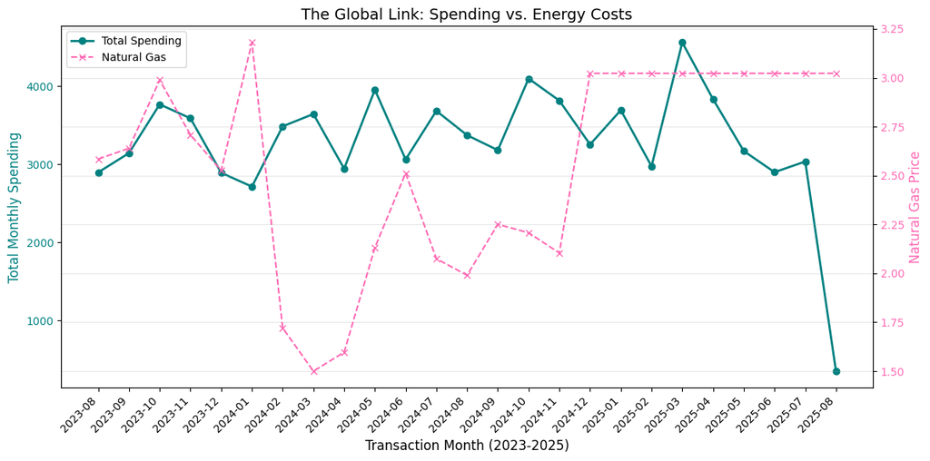

```python
import matplotlib.pyplot as plt

#make month a string for plotting
joined_df_one['month_str'] = joined_df_one['month'].astype(str)

#create subplots for labeling
fig, ax1 = plt.subplots(figsize=(12, 6))

#left y axis for total spending
ax1.plot(joined_df_one['month_str'], joined_df_one['final_amount'],
         label='Total Spending', color='teal', linewidth=2, marker='o')

#makes month easier to read and makes them in line with ticks
ax1.set_xticks(range(len(joined_df_one['month_str'])))
ax1.set_xticklabels(joined_df_one['month_str'], rotation=45, ha='right')

#labels and colors
ax1.set_xlabel('Transaction Month (2023-2025)', fontsize=12)
ax1.set_ylabel('Total Monthly Spending', color='teal', fontsize=12)
ax1.tick_params(axis='y', labelcolor='teal')

#right y axis for natural gas
ax2 = ax1.twinx()
ax2.plot(joined_df_one['month_str'], joined_df_one['natural_gas_us'],
         label='Natural Gas', color='hotpink', linestyle='--', marker='x')

#labels and colors
ax2.set_ylabel('Natural Gas Price', color='hotpink', fontsize=12)
ax2.tick_params(axis='y', labelcolor='hotpink')

#title
plt.title("The Global Link: Spending vs. Energy Costs", fontsize=14)

#creates legend for both lines
lines1, labels1 = ax1.get_legend_handles_labels()
lines2, labels2 = ax2.get_legend_handles_labels()
ax1.legend(lines1 + lines2, labels1 + labels2, loc='upper left')
plt.grid(True, alpha=0.3)
plt.tight_layout()
plt.show()
```

### Identifying Latency (3 Month Shift)

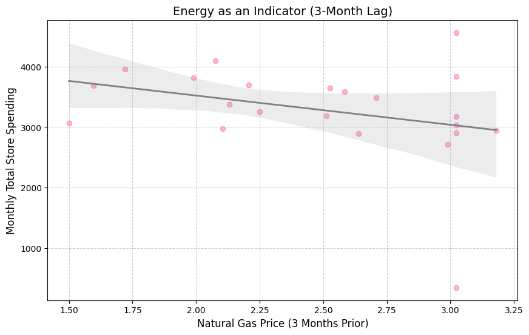

```python
import matplotlib.pyplot as plt
import seaborn as sns

plt.figure(figsize=(10, 6))

#3 month lag of natural gas
gas_lag = joined_df_one['natural_gas_us'].shift(3)

#used regplot to show trend line and scatter points of final amount
sns.regplot(x=gas_lag,
            y=joined_df_one['final_amount'],
            scatter_kws={'color':'hotpink', 'alpha':0.5},
            line_kws={'color':'grey', 'lw':2})

#plot labels and output
plt.title("Energy as an Indicator (3-Month Lag)", fontsize=14)
plt.xlabel("Natural Gas Price (3 Months Prior)", fontsize=12)
plt.ylabel("Monthly Total Store Spending", fontsize=12)
plt.grid(True, linestyle='--', alpha=0.6)
plt.show()
```

## 3. Models:

### Market Volume Spending (Sum Model)

What factors most strongly influence total grocery spending, and what role do global commodity prices play in grocery store revenue?

This model shows the health of the global market. If certain commodities become expensive, the grocery bill will either rise or decrease based on how consumers will buy or not buy. By modeling final_amount summed, global fluctuations can be analyzed by their effect on total revenue.

Dependent variable is sum(final_amount). This represents total spending across transactions for the month.

Independent Variables are commodity prices such as beef, chicken, natural_gas_us, maize, rice_thai_5%, wheat_us_hrw, and crude_oil_master. These variables affect total costs through supply chain influences. Additional variables such as discount_price, sum(quantity), and avg(unit_price) are included to reflect total purchasing behavior.

Model Type: Multi-Variable Linear Regression Model to evaluate how total revenue volume is influenced by commodity prices and purchasing activity.

Model Idea: This model applies multi-variable Linear Regression to determine how global commodity prices influence the total volume of grocery spending. This will show purchasing behavior and transaction volume. Results from this model will provide insights in revenue impacts.

### Implementation of Market Volume Model (Sum Model)

```python
from sklearn.model_selection import train_test_split
from sklearn.metrics import mean_squared_error, r2_score
from sklearn.linear_model import LinearRegression


#creation of lagged variable of crude oil
joined_df_one["oil_lag1"] = joined_df_one["crude_oil_master"].shift(1)

#drop nan values created with the lagged
df_lag = joined_df_one.dropna()

#grab features from the new lagged dataset
#independent variables
X = df_lag[[
    "oil_lag1", "beef", "chicken","rice_thai_5%", "natural_gas_us", "wheat_us_hrw", "crude_oil_master", "quantity", "unit_price", "discount_amount", "maize"
]]
#dependent variable
y = df_lag["final_amount"]

#train/test split
X_train_s, X_test_s, y_train_s, y_test_s = train_test_split(
    X, y, test_size=0.2, random_state=42
)

#linear regression
lr = LinearRegression()

#model training
lr.fit(X_train_s, y_train_s)

#prediction step for final amount on real data
y_pred_lr_sum = lr.predict(X_test_s)

#output with performance metrics
print("Linear Regression Sum")
print("MSE:", mean_squared_error(y_test_s, y_pred_lr_sum))
print("R²:", r2_score(y_test_s, y_pred_lr_sum))

#see which variables have the strongest predictions
lr_coeffs_sum = pd.Series(lr.coef_, index=X.columns).sort_values(ascending=False)
print(lr_coeffs_sum)
```

```
Linear Regression Sum
MSE: 72918.4518050765
R²: 0.6986282950842271
unit_price          172.855097
discount_amount     148.256597
oil_lag1             22.699193
quantity             12.980236
rice_thai_5%          0.269384
wheat_us_hrw         -0.723497
maize                -4.212179
crude_oil_master    -23.068463
natural_gas_us      -52.163853
beef                -76.444714
chicken            -378.733080
dtype: float64
```

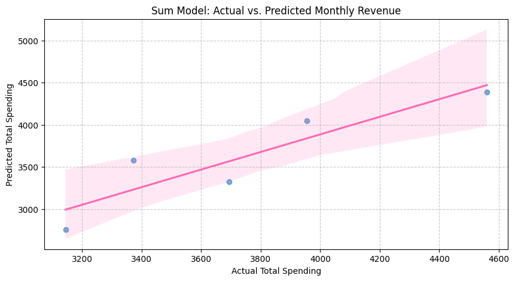

```python
import matplotlib.pyplot as plt
import seaborn as sns


plt.figure(figsize=(10, 5))
#regression plot creation of linear regression above
sns.regplot(x=y_test_s, y=y_pred_lr_sum, scatter_kws={'alpha':0.6}, line_kws={'color':'hotpink'})

#labels and output
plt.title('Sum Model: Actual vs. Predicted Monthly Revenue')
plt.xlabel('Actual Total Spending')
plt.ylabel('Predicted Total Spending')
plt.grid(True, linestyle='--', alpha=0.7)
plt.show()
```

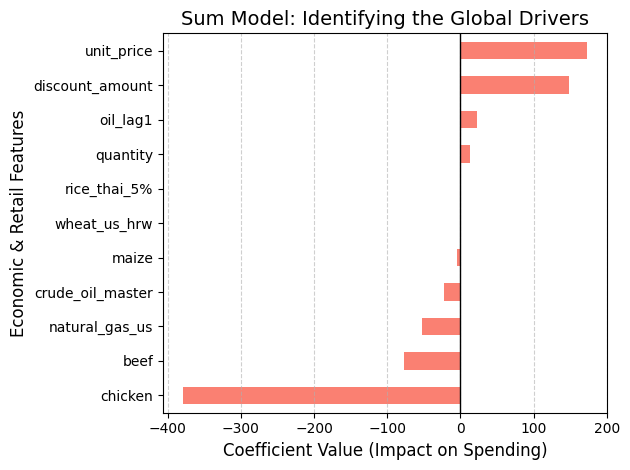

```python
import matplotlib.pyplot as plt
import pandas as pd

#Linear Regression coefficients
lr_coeffs = pd.Series(lr.coef_, index=X.columns).sort_values()

#plotting coefficients
lr_coeffs.plot(kind='barh', color='salmon')

#ouput and labels
plt.title('Sum Model: Identifying the Global Drivers', fontsize=14)
plt.xlabel('Coefficient Value (Impact on Spending)', fontsize=12)
plt.ylabel('Economic & Retail Features', fontsize=12)
plt.axvline(x=0, color='black', linestyle='-', linewidth=1)
plt.grid(axis='x', linestyle='--', alpha=0.6)
plt.tight_layout()
plt.show()
```

The Linear Regression Sum Model achieved R² of 70%. This indicates that 70% of the variation in monthly grocery revenue is explained by the model's features Unit Price and Discount Amount are the strongest positive predictors. While Chicken and beef are the lowest negative predictors. Unit Price being the highest predictor is no shocker since as that goes up to does the grocery store revenue. However, since beef and chicken are negative coefficients it might suggest that consumers may reduce their spending on those items, substitute them, or may not get as much items are they used to. This model shows that grocery stores are the primary factors on the price that consumers pay. The global commodities are more like guides on where those prices should be. The inclusion of the lagged oil variable (oil_lag1) suggests that increases in oil prices may impact grocery spending with a delay. In the contrast, the current crude oil master variable shows a more negative relationship implying that price adjustments at the store level do not happen immediately.

### Determinants of Consumer Spending (Mean Model)

What factors most strongly influence total grocery spending, and what role do global commodity prices play?

If commodities become expensive then customers may buy less, choose different products, or may use discounts. With final_amount being modeled, global fluctuations can be montitored to see how they affect consumer bills.

Dependent variable is mean(final_amount). This provides the total amount each bill cost to help with finding if the independent variables individual increases affect the total spent bill.

Independent Variables are commodity prices such as beef, chicken, natural_gas_us, maize, rice_thai_5%, wheat_us_hrw, crude_oil_master. These variables affect the food cost through things like transportation/making of food. In addition, other variables like discount_price, quantity, and unit_price also affect the total bill from the grocery side.

Model Type: Multi-Variable Linear Regression Model as a basline to see how the average bill spending gets impacted from any commodity prices.

Model Idea: This model will have a mutli-variable Linear Regression to identify how global commodities, specifically energy and livestock, influence the average grocery bill. To help focus on the energy protion for the global scale, lagged variables will be used to test the hypothesis. By comparing results with the Sum Model, global shifts can be indentified as the primary cause for item pricing (mean) or total consumer activity(sum).

### Implementation of Determinants of Consumer Spending (Mean Model)

```python
#3 month shift and drop nan values from lagged
joined_df_one["oil_lag3"] = joined_df_one["crude_oil_master"].shift(3)
df_lag = joined_df_one.dropna()

#grab independent variables
X_mean = df_lag[[
    "oil_lag3","beef", "chicken","rice_thai_5%", "natural_gas_us", "wheat_us_hrw", "crude_oil_master", "quantity_mean", "unit_price", "discount_amount", "maize"
]]

#dependent variable
y_mean = df_lag["final_amount_mean"]

#training and testing data
X_train_m, X_test_m, y_train_m, y_test_m = train_test_split(
    X_mean, y_mean, test_size=0.2, random_state=42
)

#Train Mean Model
lr_mean = LinearRegression()
lr_mean.fit(X_train_m, y_train_m)

#generate predictions on test set
y_pred_mean = lr_mean.predict(X_test_m)

#output with performance metrics
print("Linear Regression Mean")
print("MSE:", mean_squared_error(y_test_m, y_pred_mean))
print("R²:", r2_score(y_test_m, y_pred_mean))

#compare coefficients
mean_coeffs = pd.Series(lr_mean.coef_, index=X_mean.columns).sort_values(ascending=False)
print(mean_coeffs)
```

```
Linear Regression Mean
MSE: 1.3869130991532346
R²: 0.9348552977034514
quantity_mean       12.333907
chicken             11.380201
unit_price           3.461248
natural_gas_us       0.976049
beef                 0.860563
crude_oil_master     0.092632
wheat_us_hrw         0.004632
rice_thai_5%        -0.009619
maize               -0.035017
oil_lag3            -0.066677
discount_amount     -1.479778
dtype: float64
```

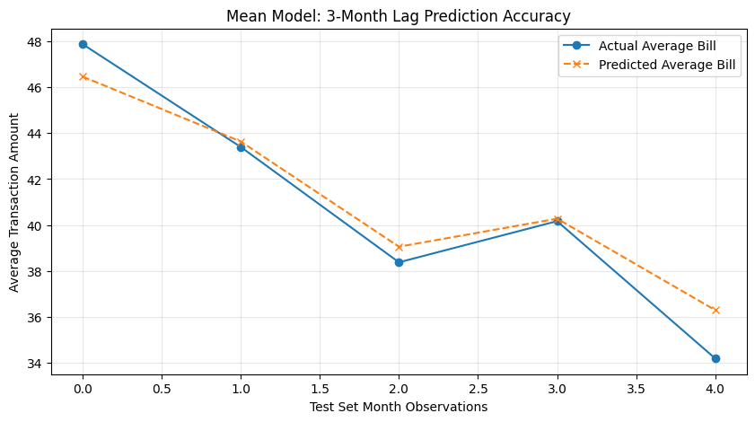

```python
plt.figure(figsize=(10, 5))
#plot values from test set  and not just index data
plt.plot(y_test_m.values, label='Actual Average Bill', marker='o', linestyle='-')
plt.plot(y_pred_mean, label='Predicted Average Bill', marker='x', linestyle='--')

#output and labels
plt.title('Mean Model: 3-Month Lag Prediction Accuracy')
plt.xlabel('Test Set Month Observations')
plt.ylabel('Average Transaction Amount')
plt.legend()
plt.grid(True, alpha=0.3)
plt.show()
```

**** The plot of actual vs. predicted values shows the model closely tracking real spending patterns, reinforcing its strong performance.**

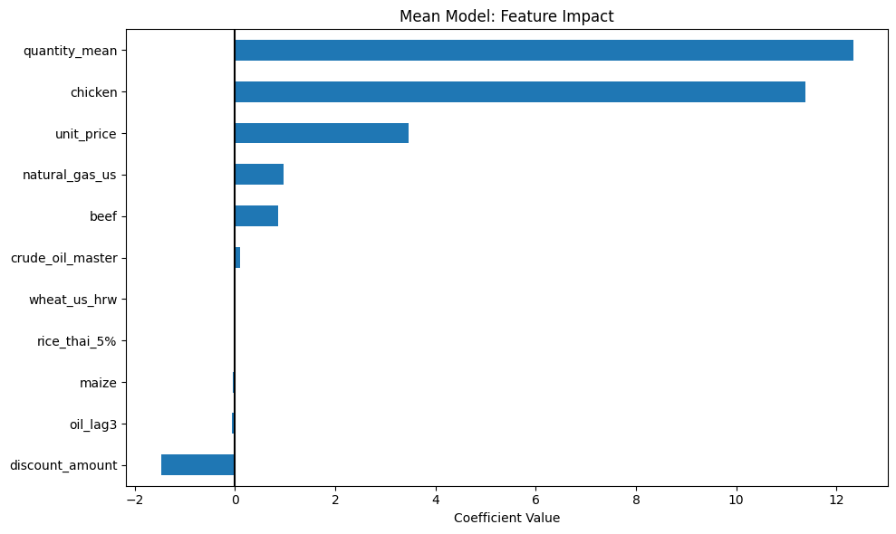

```python
#grabs coefficients and sorts them high to low
mean_coeffs = pd.Series(lr_mean.coef_, index=X_mean.columns).sort_values()

plt.figure(figsize=(10,6))

#plot as a horizontal bar chart
mean_coeffs.plot(kind='barh')

#vertical line at zero
plt.axvline(0, color='black')

#output and labels
plt.title("Mean Model: Feature Impact")
plt.xlabel("Coefficient Value")
plt.tight_layout()
plt.show()
```

The Mean Model is a 3-month shift of how the average bill spending gets impacted from any commodity prices. The Mean Model has a R² of 93.5% of variance in the average transaction amount. It also captures the delay of the global economy affecting consumers at the grocery store. These delays allow for the full costs of transportation, supply chain, and gradual price changes to be shown. The strong relationship of quantity_mean and unit_price shows how avergage spending increases when the number of items purchased and their prices increases. The average total spent is driven more by quantity and product choices (chicken, unit prices) than the immediate global commodity price fluctuations. The weak effect of oil_lag3 suggests that global commodity shocks take time to influence consumer prices and may not show the most evident impact immediately. While this model shows very strong performance. A TimeSeriesSplit Ridge Regression model would be better to confirm if this performance hold in real world scenarios.

### Model Reliability with Multicollinearity

To improve model reliability can multicollinearity among commodity variables be addressed?

Commodity prices are highly dependent on each other, especially across energy and agricultural markets. This dependency can sometimes overestimate one coefficient. Ridge regression helps reduce this issue by regularization.

Dependent variable is final_amount (mean). Shows the full total affect three month later.

Independent Variables include the same commodity prices (beef, chicken, natural_gas_us, maize, rice_thai_5%, wheat_us_hrw, crude_oil_master) along with discount_price, quantity (mean or sum), and unit_price.

Model Type: Ridge Regression Model used to improve coefficient stability and reduce overfitting.

Model Idea: Ridge regression uses a penalty (alpha) to shrink coefficients. This ensures no single commodity dominates the model. The Ridge model validates and refine the results from the linear regression models. This provide stability and higher confidence in the interpretation of how global commodity prices influence grocery spending.

```python
from sklearn.model_selection import TimeSeriesSplit
from sklearn.linear_model import Ridge
from sklearn.metrics import mean_squared_error, r2_score
import numpy as np

#data sorted by month
df_timeseries = df_lag.sort_values("month")

#preps features and dependent variable
X_ts = df_timeseries[[
    "beef", "chicken", "rice_thai_5%", "natural_gas_us",
    "wheat_us_hrw", "quantity_mean", "unit_price",
    "discount_amount", "maize", "oil_lag3"
]]
y_ts = df_timeseries["final_amount_mean"]

#create TimeSeriesSplit with 5 splits across model at different times
tscv = TimeSeriesSplit(n_splits=5)

#list to store performance metrics
mse_scores = []
r2_scores = []

print("Time Series Split Validation (Ridge)")

#cross validation loop of splits
for train_index, test_index in tscv.split(X_ts):
    #Split the data into past and futures (training and testing)
    X_train, X_test = X_ts.iloc[train_index], X_ts.iloc[test_index]
    y_train, y_test = y_ts.iloc[train_index], y_ts.iloc[test_index]

    #train model on past training
    #add penalty alpha = 1 to size of coefficients
    ridge_ts = Ridge(alpha=1.0)
    ridge_ts.fit(X_train, y_train)

    #predict on future testing
    y_pred = ridge_ts.predict(X_test)

    #performance metrics for fold
    mse_scores.append(mean_squared_error(y_test, y_pred))
    r2_scores.append(r2_score(y_test, y_pred))

#calculate average performance
print(f"Average MSE: {np.mean(mse_scores):.4f}")
print(f"Average R²: {np.mean(r2_scores):.4f}")

#view coefficients of final fold
ridge_coeffs = pd.Series(ridge_ts.coef_, index=X_ts.columns).sort_values(ascending=False)
print("\nFeature Coefficients (Final Fold):")
print(ridge_coeffs)
```

```
Time Series Split Validation (Ridge)
Average MSE: 9.8348
Average R²: -1.0449

Feature Coefficients (Final Fold):
unit_price         3.017221
quantity_mean      1.815311
discount_amount    1.317473
natural_gas_us     0.390642
chicken            0.347092
wheat_us_hrw       0.002289
oil_lag3          -0.007984
rice_thai_5%      -0.021654
maize             -0.030696
beef              -1.663401
dtype: float64
```

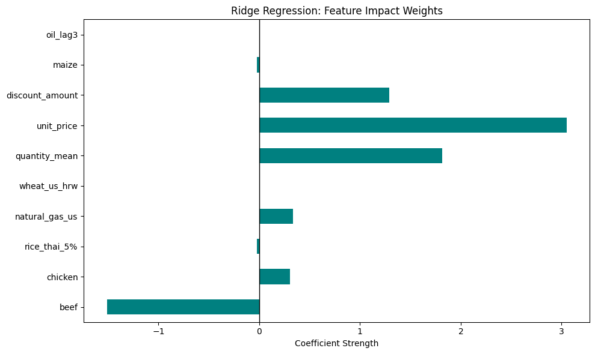

```python
#average coefficients across all folds
ridge_final = Ridge(alpha=1.0)
ridge_final.fit(X_ts, y_ts)

#series to get features and weights
ridge_coeffs = pd.Series(ridge_final.coef_, index=X_ts.columns)

#output and labels
plt.figure(figsize=(10, 6))
ridge_coeffs.plot(kind='barh', color='teal')
plt.title('Ridge Regression: Feature Impact Weights')
plt.xlabel('Coefficient Strength')
plt.axvline(0, color='black', lw=1)
plt.tight_layout()
plt.show()
```

Ridge Regression stabilized the Linear Regression Mean Model coefficients which handle the correlation between energy and agricultural commoditites. Unit Price and Quantity are the strongest grocery store drivers, while Natural Gas and Chicken are the global commodity drivers. This shows that chicken may be substituted for beef because of their opposite signed coefficients. But this relationship is not confirmed because of the how low the Ridge model's predicitve performance is. Ridge Regression helped reduce coefficient variance, but it does not improve accuracy because of its negative R². Another reason the R² could be very low is because of the difference in prices from 2023 to 2025. Since this model is being predicted using historical data. This means that the global commodities and grocery bills prices are always evolving and not stationary.

### Model Comparison: Total Revenue vs. Average Transaction

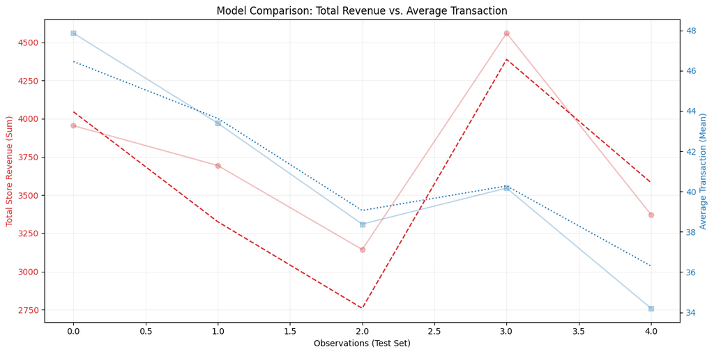

```python
import matplotlib.pyplot as plt

fig, ax1 = plt.subplots(figsize=(12, 6))

#Sum Model left y
color_sum = 'tab:red'
ax1.set_xlabel('Observations (Test Set)')
ax1.set_ylabel('Total Store Revenue (Sum)', color=color_sum)
#ploting values
ax1.plot(y_test_s.values[:50], label="Actual (Sum)", color=color_sum, alpha=0.3, marker='o')
ax1.plot(y_pred_lr_sum[:50], label="Predicted (Sum)", color=color_sum, linestyle='--')
ax1.tick_params(axis='y', labelcolor=color_sum)

#Mean Model right y
ax2 = ax1.twinx()
color_mean = 'tab:blue'
ax2.set_ylabel('Average Transaction (Mean)', color=color_mean)
#plotting values
ax2.plot(y_test_m.values[:50], label="Actual (Mean)", color=color_mean, alpha=0.3, marker='s')
ax2.plot(y_pred_mean[:50], label="Predicted (Mean)", color=color_mean, linestyle=':')
ax2.tick_params(axis='y', labelcolor=color_mean)

#output
plt.title("Model Comparison: Total Revenue vs. Average Transaction")
fig.tight_layout()
ax1.grid(True, alpha=0.2)
plt.show()
```

### Comparing Coefficients of Each Model

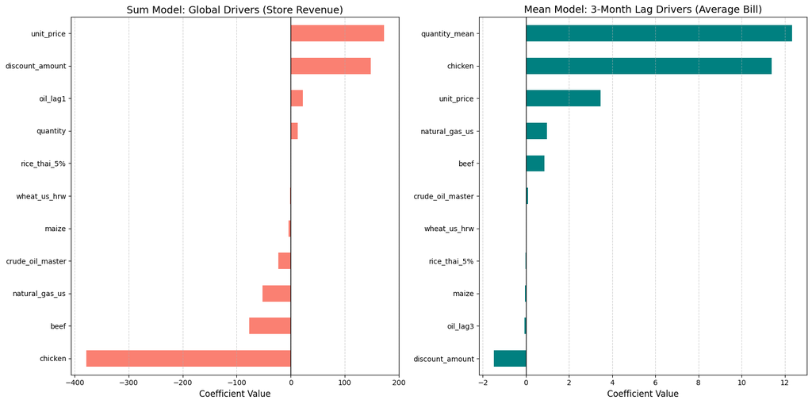

```python
import matplotlib.pyplot as plt

#subplots side by side
fig, (ax1, ax2) = plt.subplots(1, 2, figsize=(16, 8))

#sum model bar horizontal chart
lr_coeffs_sum.sort_values().plot(kind='barh', ax=ax1, color='salmon')
ax1.set_title("Sum Model: Global Drivers (Store Revenue)", fontsize=14)
ax1.set_xlabel("Coefficient Value", fontsize=12)
#vertical line at zero
ax1.axvline(0, color='black', linestyle='-', linewidth=1)
ax1.grid(axis='x', linestyle='--', alpha=0.6)

#Mean Model bar horizontal chart
mean_coeffs.sort_values().plot(kind='barh', ax=ax2, color='teal')
ax2.set_title("Mean Model: 3-Month Lag Drivers (Average Bill)", fontsize=14)
ax2.set_xlabel("Coefficient Value", fontsize=12)
#vertical line at zero
ax2.axvline(0, color='black', linestyle='-', linewidth=1)
ax2.grid(axis='x', linestyle='--', alpha=0.6)

#outputd
plt.tight_layout()
plt.show()
```

The two horizonatal bar charts showcase the coefficients of the Sum and Mean Model allowing for comparison between each feature and how each variables' shifts affects each prediction. Unit Price and Quantity are two positive predictors for each model. Also in the two graph chicken for the Sum Model and discount amount for the Mean show how they negatively impact revenue and consumer speading.

### Violin Plot of Both Models Residuals

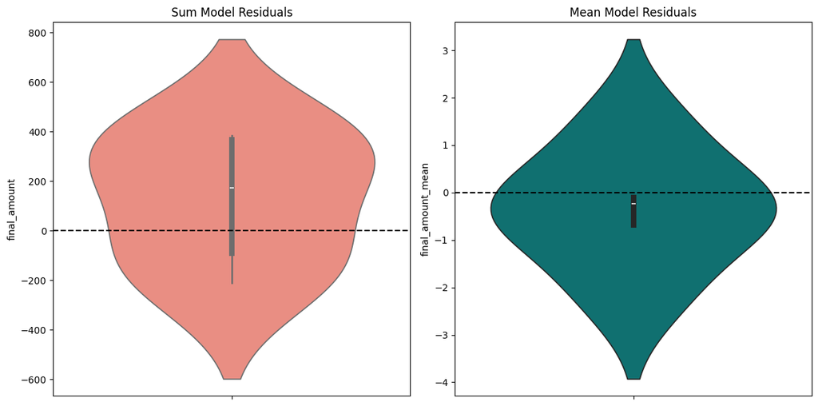

```python
#create two subplot of individual models
fig, (ax1, ax2) = plt.subplots(1, 2, figsize=(12, 6))

#residuals calculations
res_sum = y_test_s - y_pred_lr_sum
res_mean = y_test_m - y_pred_mean

#combine into one df
res_df = pd.DataFrame({
    "Sum Model": res_sum.values,
    "Mean Model": res_mean.values
})

#Sum Model Violin
#add median and quartiles
sns.violinplot(y=res_sum, ax=ax1, color="salmon", inner="box")
ax1.set_title("Sum Model Residuals")
#horizontal reference line
ax1.axhline(0, color='black', linestyle='--')

#Mean Model Violin
#add median and quartiles
sns.violinplot(y=res_mean, ax=ax2, color="teal", inner="box")
ax2.set_title("Mean Model Residuals")
#horizontal reference line
ax2.axhline(0, color='black', linestyle='--')

#output
plt.tight_layout()
plt.show()
```

The two violin plots above display the prediction residuals for each model. The Sum Model shows asymmetry and a fluctuating error range. The fluctuating error range reflects the violatitility of total store revenue. This shows that the grocery stores have more influence on prices rather than global commodities that act more like price guides. The Mean Model shows a symmertrical distribution centered around zero. The Mean Model shows a smaller range of errors indicataing that the 3-month lag variables are capturing accurate economic shifts with little bias. These two graphs show how the Mean Model is a better prediction tool because of its accuracy and precision. It shows that while total store revenue is high variance, predicting the average consumer shifts is more stable and accurate.

## 4. Conclusion

The objective of this analysis was to determine how global economic commodities diffuse through the supply chain to incluence grocery retail transactions. By combining global commodity data and grocery store transaction data and using Linear Regression and Ridge Regression, several relationships appeared.

Global commodity prices such as oil, wheat, and natural gas have weaker and less consistent effects immediately shown on grocery spending. While lagged oil prices suggest that grocery costs receive a delayed reaction because of things within the supply chain like transportation and product making. The Mean Linear Regression provided the strongest predictive performanace, while Ridge Regression improved the coefficient stability but did not enhance accuracy.

Based on these findings, grocery stores should prioritze price strategies and demand driven factors when aiming to increase revenue. Since discounts and unit prices strongly affect spending, prize optimization from the grocery store is more effective than forecasting global commodity indices. Additionally, grocery store need to account for delayed effects from the commodities when planning long term price adjustments.

Overall, grocery spending is driven by the grocery store factors like unit price and discount amounts, while global comodity factors act a guide and play a more indirect role in price fluctuations.